# Análisis de la Esperanza de Vida en Diferentes Regiones del Mundo

##### Corrupción

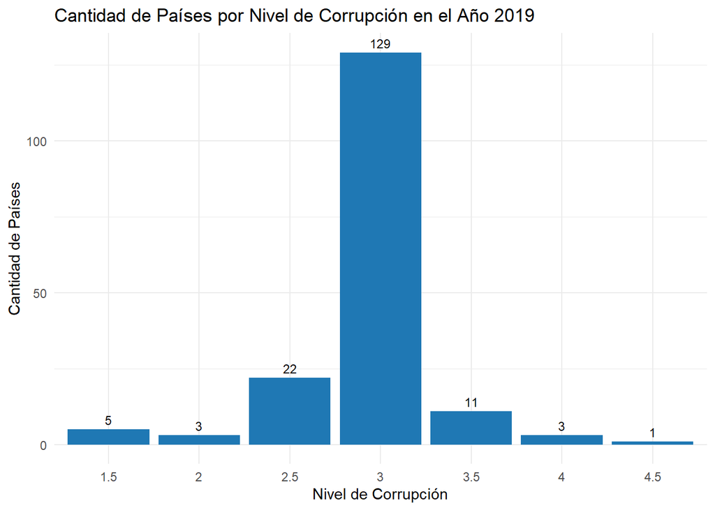

```r
cantidad_paises_por_corrupcion <- datos_2019 %>%
  group_by(Corruption) %>%
  summarise(Cantidad_Paises = n())

# Mostrar el resultado
ggplot(cantidad_paises_por_corrupcion, aes(x = factor(Corruption), y = Cantidad_Paises)) +
  geom_bar(stat = "identity", fill = "#1f78b4") +
  geom_text(aes(label = Cantidad_Paises), vjust = -0.5, size = 3) +
  labs(x = "Nivel de Corrupción", y = "Cantidad de Países",
       title = "Cantidad de Países por Nivel de Corrupción en el Año 2019") +
  theme_minimal()
```

El gráfico de barras proporcionado muestra la cantidad de países por nivel de corrupción en el año 2019. En esta interpretación:

El eje x representa los diferentes niveles de corrupción.

El eje y representa la cantidad de países en cada nivel de corrupción.

Los datos indican que el nivel de corrupción con la mayor cantidad de países es el nivel 3, con un total de 129 países. Por otro lado, el nivel de corrupción con la menor cantidad de países es el nivel 4.5, con solo 1 país.

Estos resultados destacan una variación significativa en los niveles de corrupción entre los diferentes países del mundo. Específicamente, se observa que hay una mayor cantidad de países en el nivel 3 de corrupción y una menor cantidad en el nivel 4.5.

### Estimacion muestral:

## Proporciones

### Proporcion de regiones con bajos ingresos

```r
Ingresos <- ifelse(life_expectancy$IncomeGroup== "Low income",1,0)

str(Ingresos)
```

```
##  num [1:174] 0 0 0 0 0 0 0 0 0 0 ...
```

```r
prop.table(table(Ingresos))
```

```
## Ingresos
##         0         1
## 0.8678161 0.1321839
```

```r
Ingresos <- na.omit(Ingresos)

p <- mean(Ingresos)

p
```

```
## [1] 0.1321839
```

```r
#Identificar el n

n <- length(Ingresos)
n
```

```
## [1] 174
```

```r
#error estandar

error.est.p <- sqrt((p*(1-p))/n)

#cálculo del error
error.p <- 1.96*error.est.p

#limites
lim.inf <- p-error.p
lim.sup <- p+error.p

intervalo.p <- data.frame(n,p,error.est.p,error.p,lim.inf,lim.sup)

intervalo.p
```

```
##     n         p error.est.p    error.p    lim.inf  lim.sup
## 1 174 0.1321839  0.02567607 0.05032509 0.08185881 0.182509
```